# Logistic regression and L-1 regularization

Brendan Mapes

10/29/2021

*Considering the ChickWeight data in R. The body weights of the chicks were measured at birth (i.e., time=0) and every second day thereafter until day 20. They were also measured on day 21. There were four groups of chicks on different protein diets. Categorizing‘weight’ as a binary variable, with WeightGroup = 1 (or Low), if weight < 110 mg, and 0, Otherwise.*

*Comparing Diet Levels 1 and 4 on Day 21.*

```r
day_21 <- chick %>% filter(Time == 21)
diet_1_4 <- day_21 %>% filter(Diet == 1 | Diet == 4)
```

*Determining whether there is association between Diet and WeightGroup, using logistic regression, without adjusting for Birth Weight. Interpreting estimated parameters.*

```r
logreg_1a <- glm(weightgroup ~ Diet, family=binomial, diet_1_4)
summary(logreg_1a)
```

```
##
## Call:
## glm(formula = weightgroup ~ Diet, family = binomial, data = diet_1_4)
##
## Coefficients:
##              Estimate Std. Error z value Pr(>|z|)
## (Intercept)   -1.9459     0.7559  -2.574    0.010 *
## Diet4        -17.6202  3584.6711  -0.005    0.996
## ---
## Signif. codes:  0 '***' 0.001 '**' 0.01 '*' 0.05 '.' 0.1 ' ' 1
##
## (Dispersion parameter for binomial family taken to be 1)
##
##     Null deviance: 13.938  on 24  degrees of freedom
## Residual deviance: 12.057  on 23  degrees of freedom
## AIC: 16.057
##
## Number of Fisher Scoring iterations: 18
```

The estimated parameter for Diet 4 (-17.6202) is not statistically significant. However, if it were, it could be interpreted as follows: On average, the switch from diet 1 to diet 4 corresponds to a logit odds (log-of-odds) decrease in the dependent variable of study here, weightgroup. Weightgroup has been coded here so 1 represents low weight (as directions for problem requested) and 0 equals high weight (at or above 110 mg). So, more generally, logistic regression would suggest that the switch from diet 1 to diet 4 corresponds to a shift towards the high class of the weightgroup variable. Diet “switch” is not intended to be a literal term, but simply suggests this is the change that occurs when comparing the two diet groups, when considering diet 1 the “baseline” diet. The true meaning of the logit odds is a bit of a mystery, but generally its results can be understood in this way. Regardless, the results here suggest a statistically insignificant result and a lack of correlation in reality.

*Repeating (a) adjusting for Birth Weight. Interpreting the estimated parameters.*

```r
day_0 <- chick %>% filter(Time == 0)
day_0 <- day_0 %>% select(Chick, weight)
day_0 <- rename(day_0, birth_weight = weight)
diet_1_4 <- left_join(diet_1_4, day_0, by = "Chick")

logreg_1b <- glm(weightgroup ~ Diet + birth_weight, family=binomial, diet_1_4)
summary(logreg_1b)
```

```
##
## Call:
## glm(formula = weightgroup ~ Diet + birth_weight, family = binomial,
##     data = diet_1_4)
##
## Coefficients:
##                Estimate Std. Error z value Pr(>|z|)
## (Intercept)     2.08403   36.84523   0.057    0.955
## Diet4         -17.68625 3582.23136  -0.005    0.996
## birth_weight   -0.09702    0.88746  -0.109    0.913
##
## (Dispersion parameter for binomial family taken to be 1)
##
##     Null deviance: 13.938  on 24  degrees of freedom
## Residual deviance: 12.045  on 22  degrees of freedom
## AIC: 18.045
##
## Number of Fisher Scoring iterations: 18
```

*Repeating for all 4 Diet Levels*

```r
all_diets <- day_21
all_diets <- left_join(all_diets, day_0, by = "Chick")

#not adjusting for birth weight
logreg_2a <- glm(weightgroup ~ Diet, family=binomial, all_diets)
summary(logreg_2a)
```

```
##
## Call:
## glm(formula = weightgroup ~ Diet, family = binomial, data = all_diets)
##
## Coefficients:
##              Estimate Std. Error z value Pr(>|z|)
## (Intercept)   -1.9459     0.7559  -2.574    0.010 *
## Diet2         -0.2513     1.2971  -0.194    0.846
## Diet3        -18.6202  5606.8353  -0.003    0.997
## Diet4        -18.6202  5910.1234  -0.003    0.997
## ---
## Signif. codes:  0 '***' 0.001 '**' 0.01 '*' 0.05 '.' 0.1 ' ' 1
##
## (Dispersion parameter for binomial family taken to be 1)
##
##     Null deviance: 22.044  on 44  degrees of freedom
## Residual deviance: 18.558  on 41  degrees of freedom
## AIC: 26.558
##
## Number of Fisher Scoring iterations: 19
```

```r
#adjusting for birth weight
logreg_2b <- glm(weightgroup ~ Diet + birth_weight, family=binomial, all_diets)
summary(logreg_2b)
```

```
##
## Call:
## glm(formula = weightgroup ~ Diet + birth_weight, family = binomial,
##     data = all_diets)
##
## Coefficients:
##                Estimate Std. Error z value Pr(>|z|)
## (Intercept)   -17.76110   24.30070  -0.731    0.465
## Diet2           0.00222    1.34073   0.002    0.999
## Diet3         -18.33416 5557.60421  -0.003    0.997
## Diet4         -18.37111 5853.83295  -0.003    0.997
## birth_weight    0.37954    0.58139   0.653    0.514
##
## (Dispersion parameter for binomial family taken to be 1)
##
##     Null deviance: 22.044  on 44  degrees of freedom
## Residual deviance: 18.116  on 40  degrees of freedom
## AIC: 28.116
##
## Number of Fisher Scoring iterations: 19
```

Again, there are no statistically significant results for these models, suggesting no relationship between diets and weight when classified as a binary variable in weight group, even when controlling for birth weight. Results for the logistic regression models here can be interpreted similarly to those of the previous problem for each of the given diet groups. However, again, these results appear to be statistically insignificant, suggesting interpretation of these variables may not be trustworthy.

When controlling for birth weight the diet2 coefficient is 0.00222, which means that a switch from diet 1 to diet 2 corresponds to a 0.00222 increase in the log odds of the dependent variable weightgroup, or a 0.00222 shift in the log odss towards the low weightgroup class.

When controlling for birth weight, the diet3 coefficient suggests the switch from diet 1 to diet 3 corresponds to a 18.33416 drop in the log odds of weightgroup, or a shift in log odds that favors the high weight class.

When controlling for birth weight, the diet4 coefficient suggests the switch from diet 1 to diet 4 corresponds to a 18.37111 drop in the log odds of the dependndent variable, or a shift in the log odds that favors the high weight class in weightgroup. The birth_weight coefficient of 0.37954 suggests that, net of diet group, a one unit (mg) increase in birth weight corresponds to a 0.37954 increase in the log odds of weight group, or a shift in the log odds that favors the low weight group, which is odd.

The results of the model that doesn’t control for birth weight can be interpreted very similarly, with almost identical results for each diet group, except in the case of diet2, where the sign is reversed, suggesting a decrease in the log odds of weight group, corresponding to the switch from diet 1 to diet 2.

Again, its important to note all these results are statistically insignificant. One important clarification: when the terms “switch from one diet group to another” are used throughout these descriptions, it simply means those two diets are being compared with the first diet being considered sort of a baseline, not that a chick has literally been switched which diet they are on.

*Repeating using the L-1 regularized logistic regression*

```r
#not controlling for birth_weight
library(glmnet)
x <- diet_1_4 %>% select(Diet, birth_weight) %>% data.matrix()
y <- diet_1_4$weightgroup %>% data.matrix()

l1_logreg <- glmnet(x,y)
summary(l1_logreg)
```

```
##           Length Class     Mode
## a0         61    -none-    numeric
## beta      122    dgCMatrix S4
## df         61    -none-    numeric
## dim         2    -none-    numeric
## lambda     61    -none-    numeric
## dev.ratio  61    -none-    numeric
## nulldev     1    -none-    numeric
## npasses     1    -none-    numeric
## jerr        1    -none-    numeric
## offset      1    -none-    logical
## call        3    -none-    call
## nobs        1    -none-    numeric
```

```r
cvfit <- cv.glmnet(x,y)
```

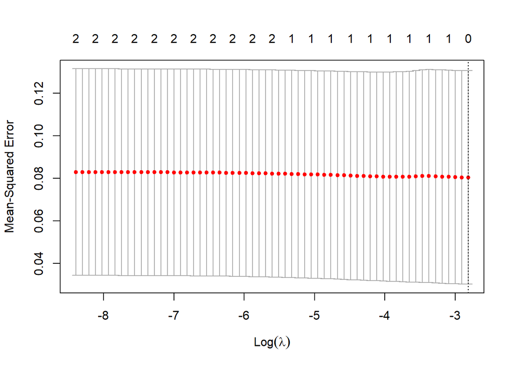

```r
plot(cvfit)
```

```r
coef(cvfit)
```

```
## 3 x 1 sparse Matrix of class "dgCMatrix"
##                s1
## (Intercept)  0.08
## Diet         .
## birth_weight .
```

```r
x <- diet_1_4 %>% select(Diet, Chick) %>% data.matrix()
y <- diet_1_4$weightgroup %>% data.matrix()

l1_logreg_a <- glmnet(x,y)
summary(l1_logreg)
```

```
##           Length Class     Mode
## a0         61    -none-    numeric
## beta      122    dgCMatrix S4
## df         61    -none-    numeric
## dim         2    -none-    numeric
## lambda     61    -none-    numeric
## dev.ratio  61    -none-    numeric
## nulldev     1    -none-    numeric
## npasses     1    -none-    numeric
## jerr        1    -none-    numeric
## offset      1    -none-    logical
## call        3    -none-    call
## nobs        1    -none-    numeric
```

```r
cvfit <- cv.glmnet(x,y)
```

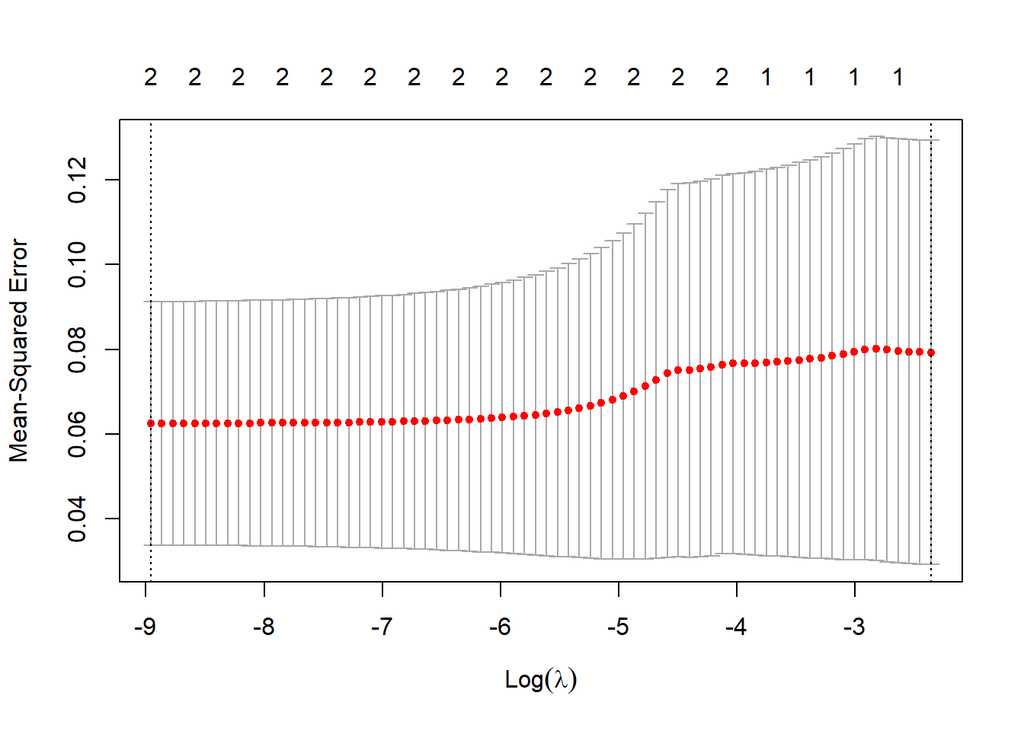

```r
plot(cvfit)
```

```r
coef(cvfit)
```

```
## 3 x 1 sparse Matrix of class "dgCMatrix"
##               s1
## (Intercept) 0.08
## Diet        .
## Chick       .
```